# Análise e Projeção da Variação de Vidas em Carteiras Coletivas Empresariais

Uma Abordagem Econométrica por Regressão Linear Multivariada

ISMAEL BARBOZA DE OLIVERA

2026-08-27

# 1 **Introdução**

A sustentabilidade da saúde suplementar exige um equilíbrio delicado para suportar a transição demográfica e a contínua escalada dos custos assistenciais, as carteiras necessitam de oxigenação constante. Em um sistema fundamentado no mutualismo onde os custos são pulverizados pelo grupo, o acelerado envelhecimento populacional e a maior frequência de utilização pressionam a despesa per capita. Nesse cenário, a capacidade de atrair, reter e prever a entrada e saída de vidas jovens e ativas é o que define a higidez financeiro-atuarial de uma operadora.

Diante disso, compreender a dinâmica de massa em contratos coletivos empresariais vai além da intuição comercial. Atualmente, a modalidade coletiva empresarial é a que predomina no mercado, representando 34.84% do total de beneficiários no Brasil.

Diante desse contexto, este trabalho propõe projetar a variação de vidas da carteira coletiva empresarial utilizando a Regressão Linear Multivariada. O objetivo é mapear a sensibilidade da massa a indicadores econômicos e operacionais (como saldo do CAGED, IPCA e Rendimento Real), fornecendo uma ferramenta quantitativa para dar suporte a precificação, planejamento orçamentário e gestão de risco atuarial.

## 1.1 **Objetivo Geral**

Modelar quantitativamente os fatores determinantes da variação da massa de beneficiários em contratos coletivos empresariais, fornecendo uma ferramenta preditiva para suporte ao pricing, à subscrição e ao controle de churn.

## 1.2 **Objetivos Específicos**

- Modelagem Regressõa Linear Multivariada: Projetar a variação percentual/líquida mensal da carteira na modalidade coletivo empresarial com base no histórico consolidado do período de 2020 a 2024.
- Estimação de Massa: Converter as variações modeladas em estimativas diretas do volume absoluto de beneficiários ativos mês a mês.

# 2 **Base de dados**

A base de dados utilizada para calcular a variação da carteira de vidas nos contratos coletivos empresariais foi extraída da mesma base pública disponibilizada e utilizada pela Agência Nacional de Saúde Suplementar (ANS) para o cálculo da Variação das Despesas Assistenciais (VDA).

Para a seleção das variáveis explicativas do modelo, foram considerados indicadores das dimensões social e econômica:

- *Dimensão Social* — Saldo do CAGED: O saldo líquido entre admissões e demissões no mercado formal de trabalho (CLT), mensurado pelo Cadastro Geral de Empregados e Desempregados (Ministério do Trabalho e Emprego).
- *Dimensão Econômica* — IPCA: O indicador oficial de inflação do país, medido pelo IBGE, que reflete a variação de preços da cesta de consumo das famílias.
- *Dimensão Econômica* — Rendimento Real Médio: O valor médio da renda habitualmente recebida pelos trabalhadores, já descontada a inflação, apurado pela PNAD Contínua do IBGE.

# 3 **Analise Descritiva**

Para compreender o comportamento da massa de beneficiários na modalidade Coletivo Empresarial, esta análise investiga a série temporal sob três perspectivas: a evolução histórica agregada, a distribuição geográfica e a segmentação por modalidade de operadora.

A carteira de beneficiários dos contratos coletivos empresariais apresenta uma sólida tendência histórica de expansão com baixa volatilidade ao longo do período de 2017 a 2024, partindo do patamar de aproximadamente 41 milhões de vidas e atingindo a marca de 60 milhões em 2024. Observa-se uma retração pontual no decorrer de 2020, movimento que reflete os impactos imediatos da pandemia de COVID-19 sobre a economia e a perda de postos de trabalho formais. Contudo, a partir de 2021, a série retoma uma trajetória de aceleração constante na adição de vidas. A Figura 1 apresenta a evolução da série temporal completa de 2017 a 2024 para a carteira de vidas na modalidade coletivo empresarial no Brasil pós-Lei nº 9.656/1998.

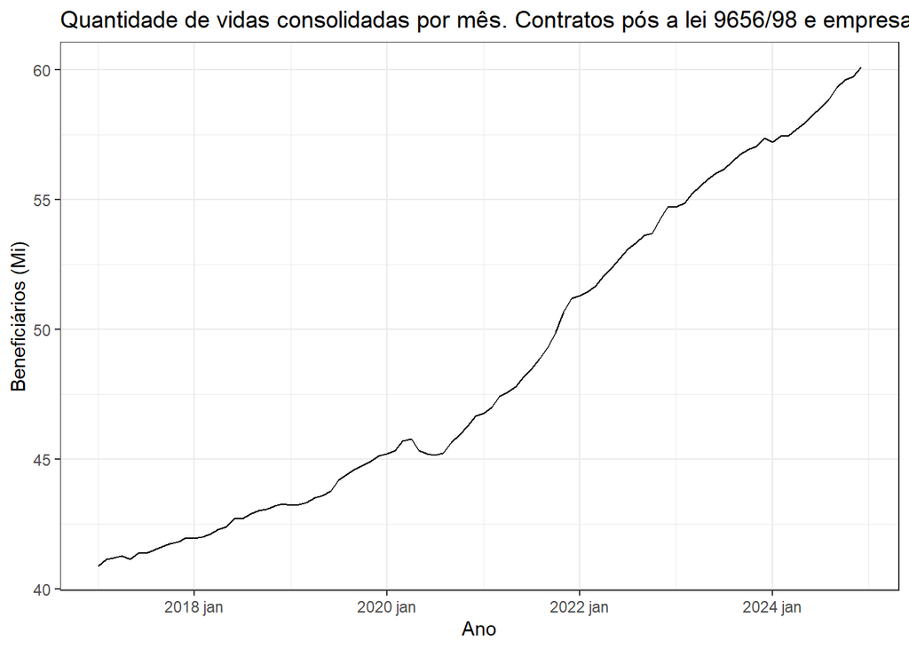

Compreendida a evolução nacional da carteira, a etapa seguinte consiste em mapear a distribuição espacial desses beneficiários. A análise geográfica evidencia uma extrema concentração da massa corporativa na Região Sudeste, que responde por 74,4% do total de vidas do país. A Região Nordeste ocupa a segunda posição com 11,4%, seguida do Sul (9,7%), enquanto Centro-Oeste (3,7%) e Norte (0,7%) mantêm participações residuais (Figura 2). Essa assimetria reflete a concentração do parque industrial e dos postos de trabalho formais no eixo Sudeste, indicando que a sensibilidade do modelo de regressão nacional será fortemente influenciada pela dinâmica econômica dessa região.

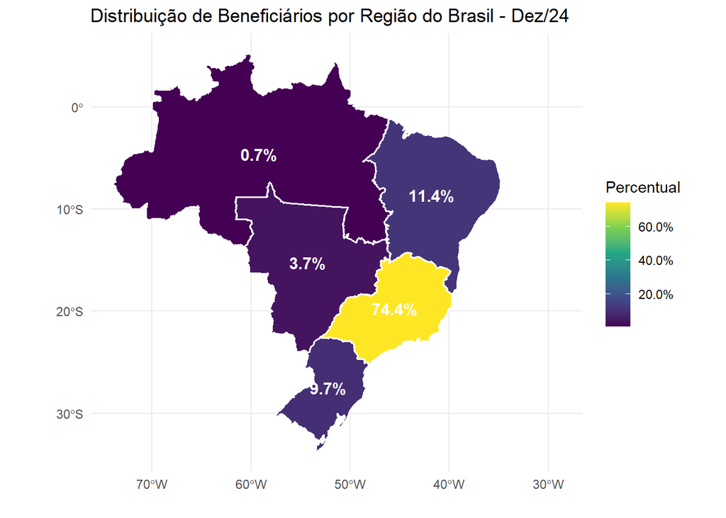

Além da concentração territorial, a estrutura de oferta do setor revela particularidades Relevantes quando segmentada por tipo de operadora. Observa-se a clara predominância da Medicina de Grupo, que lidera o segmento partindo de 13 milhões de vidas em 2017 e ultrapassando 21 milhões em 2024 (Figura 3). As Cooperativas Médicas mantêm a segunda posição (12,6 milhões em 2024), enquanto Odontologia de Grupo (10,3 milhões) e Seguradoras (9,0 milhões) apresentam crescimento paralelo e sustentado. Em contrapartida, modalidades como a Autogestão apresentam suave retração, refletindo o envelhecimento de suas bases e desafios de custos.

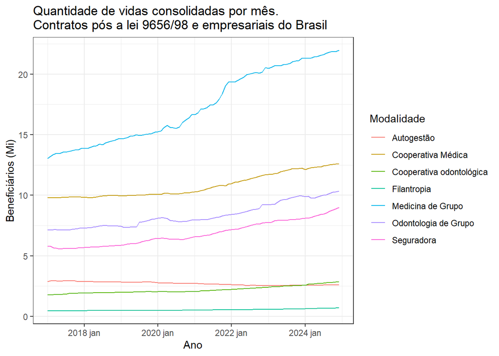

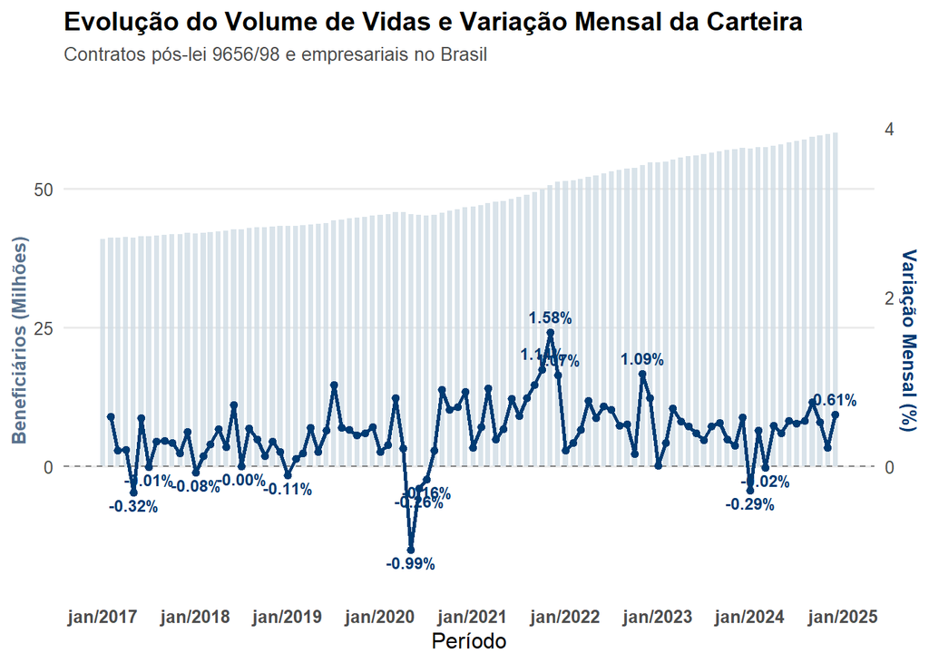

# 4 **Metodologia**

Para compreender e projetar o comportamento da massa de beneficiários na modalidade Coletivo Empresarial, adotou-se a **Regressão Linear Multivariada por Mínimos Quadrados Ordinários (MQO)**. A abordagem busca capturar a relação entre a oscilação da carteira de saúde e os ciclos econômicos do mercado de trabalho, da inflação e do nível de renda no Brasil.

## 4.1 **Tratamento de Dados e Janela Temporal**

A série histórica do volume de beneficiários encontra-se disponível desde janeiro de 2017. No entanto, devido à limitação temporal e à disponibilidade das variáveis macroeconômicas explicativas (como o Novo CAGED), o período de modelagem foi delimitado ao intervalo de **janeiro de 2020 a dezembro de 2024**.

A adoção desse período de interseção assegura o perfeito alinhamento temporal e a integridade da base de dados, permitindo a estimação do modelo multivariado sem o comprometimento da amostra por dados ausentes (*missing values*).

- **Periodicidade:** Dados mensais cobrindo o período de janeiro de 2020 a dezembro de 2024.
- **Base da Carteira ($\Delta \text{Vidas}$):** Extraída do acervo público de microdados da Agência Nacional de Saúde Suplementar (ANS), utilizando a mesma referência empregada no cálculo da Variação das Despesas Assistenciais (VDA).
- **Indicadores Externos:** Coletados via fontes oficiais do Governo Federal e do IBGE:
  - **CAGED:** Ministério do Trabalho e Emprego (MTE).
  - **IPCA e Rendimento Real Médio:** Instituto Brasileiro de Geografia e Estatística (IBGE / PNAD Contínua).

## 4.2 **Seleção de Variáveis e Estratégia de Treino e Teste**

Para mitigar o *overfitting* e garantir a capacidade preditiva do modelo fora da amostra (*out-of-sample*), a base de dados foi dividida cronologicamente na proporção de **80% para Treino** (48 observações: jan/2020 a dez/2023) e **20% para Teste** (12 observações: jan/2024 a dez/2024).

Na etapa de ajuste sobre a base de treino, considerou-se inicialmente um conjunto de 6 variáveis explicativas candidatas: **Saldo CAGED, Taxa SELIC, IPCA, Rendimento Real Médio, Produção Industrial e Poder de Compra**.

Em seguida, aplicou-se o algoritmo de seleção de variáveis *Stepwise* baseado na minimização do Critério de Informação de Akaike (AIC), que avaliou iterativamente a contribuição de cada indicador. Como resultado da otimização, o modelo final selecionou as seguintes variáveis explicativas: **Saldo CAGED (defasado em 1 mês), IPCA e Rendimento Real Médio**.

A relação funcional estimada é definida pela equação:

$$\Delta \text{Vidas}_t = \beta_0 +
\beta_1 \cdot \text{CAGED}_{t-1} + \beta_2 \cdot \text{IPCA}_t + \beta_3
\cdot \text{Rendimento}_t + \varepsilon_t$$

**Onde:**

- $\Delta \text{Vidas}_t$: Variação relativa ou líquida da massa de beneficiários no mês $t$ (variável dependente).
- $\text{CAGED}_{t-1}$: Saldo líquido de empregos formais (admissões $-$ desligamentos) com defasagem de 1 mês.
- $\text{IPCA}_t$: Variação mensal do Índice Nacional de Preços ao Consumidor Amplo.
- $\text{Rendimento}_t$: Rendimento real médio habitualmente recebido pelos trabalhadores.
- $\beta_0$: Intercepto do modelo.
- $\beta_1, \beta_2, \beta_3$: Coeficientes de sensibilidade de cada variável explicativa.
- $\varepsilon_t$: Termo de erro estocástico (resíduos).

## 4.3 **Validação e Testes de Hipóteses**

Para garantir a robustez e a confiabilidade das estimativas sem viés, o modelo passa pelos seguintes testes:

- *Qualidade de Ajuste*: Avaliação do coeficiente de determinação ($R^2$ e $R^2$ Ajustado) para medir o poder explicativo das variáveis selecionadas.
- *Significância Estatística*: Teste $t$ individual para os coeficientes ($\text{valor-}p < 0{,}05$) e Teste $F$ para a significância global do modelo.
- *Multicolinearidade*: Análise do Variance Inflation Factor (VIF) para assegurar a independência entre as variáveis explicativas ($\text{VIF} < 5$).
- *Diagnóstico de Resíduos*:
  - *Normalidade*: Teste de Shapiro-Wilk para verificar a distribuição dos erros.
  - *Homocedasticidade*: Teste de Breusch-Pagan para checar a constância da variância dos resíduos.
  - *Autocorrelação Serial*: Teste de Durbin-Watson para garantir a ausência de dependência temporal nos erros.

A tabela a seguir apresenta os resultados obtidos nos testes na validação do modelo.

Tabela 2 - Diagnóstico das Premissas do Modelo de Regressão Multivariada

| Teste | Resultado | Hipótese nula (H₀) |
| --- | --- | --- |
| Multicolinearidade (VIF) | VIF Máx = 1.2 → Sem multicolinearidade | Não há multicolinearidade relevante entre as variáveis (VIF < 5) |
| Shapiro-Wilk | p-valor = 0.2076 → Normalidade atendida | Os resíduos seguem distribuição normal |
| Breusch-Pagan | p-valor = 0.4259 → Resíduos homocedásticos | A variância dos resíduos é constante (homocedasticidade) |
| Durbin-Watson | p-valor = 0.0567 → Sem evidência de autocorrelação positiva | Não há autocorrelação positiva de 1ª ordem |
| Breusch-Godfrey (ordem 1) | p-valor = 0.202 → Sem autocorrelação de 1ª ordem | Não há autocorrelação serial até a 1ª ordem |
| Breusch-Godfrey (até ordem 12) | p-valor = 0.6314 → Sem autocorrelação até 12ª ordem | Não há autocorrelação serial até a 12ª ordem |
| Ramsey RESET | p-valor = 0.3843 → Especificação funcional adequada | A especificação funcional do modelo é adequada |

# 5 **Resultados**

O modelo de regressão baseado nas variáveis Saldo CAGED (defasado em 1 mês), IPCA e Rendimento Real Médio apresentou desempenho satisfatório, demonstrando elevada capacidade de capturar a tendência de variação na carteira de beneficiários da modalidade Coletivo Empresarial.

Na etapa de validação *out-of-sample* (projeção dos 12 meses do ano de 2024), observou-se reduzida magnitude nos erros de previsão. Como esperado em modelagens econométricas de regressão, a trajetória estimada comporta-se de maneira mais suavizada, amortecendo oscilações atípicas de curto prazo. Em março, por exemplo, a série real registrou um declínio pontual não acompanhado na mesma intensidade pelo modelo; contudo, nos meses subsequentes, as estimativas recalibraram-se rapidamente, minimizando os resíduos.

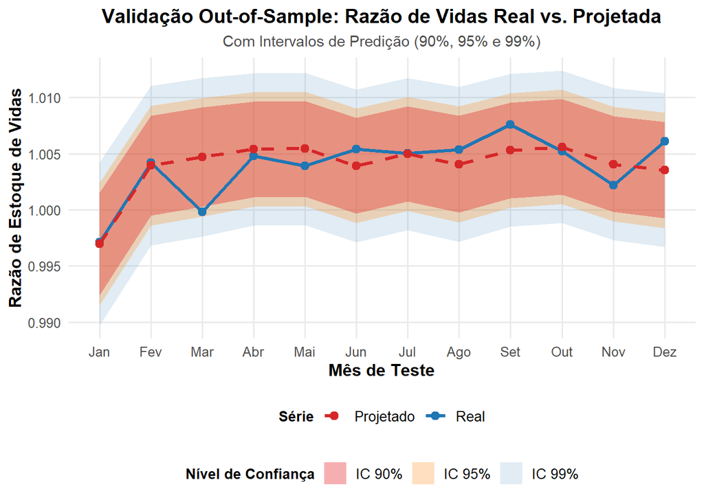

Além disso, ressalta-se que a variação real observada em todos os meses manteve-se estritamente delimitada dentro das faixas dos intervalos de predição de 95% e 99%. Esse resultado atesta a precisão do modelo e garante uma margem de segurança atuarial altamente confiável para o planejamento da carteira.

Tabela de Validação Out-of-Sample: Amostra de Teste (2024)

| Data | Projeção do Modelo Variação Projetada | Intervalo 95% IC - 95% | Intervalo 95% IC + 95% | Intervalo 99% IC - 99% | Intervalo 99% IC + 99% | Observado Variação Real | Métricas de Erro Erro Absoluto | Métricas de Erro Erro Absoluto (%) |
| --- | --- | --- | --- | --- | --- | --- | --- | --- |
| Jan | 0,9970 | 0,9915 | 1,0024 | 0,9897 | 1,0043 | 0,9971 | 0,0001 | 0,01% |
| Fev | 1,0039 | 0,9986 | 1,0093 | 0,9968 | 1,0111 | 1,0042 | 0,0003 | 0,03% |
| Mar | 1,0047 | 0,9994 | 1,0100 | 0,9976 | 1,0117 | 0,9998 | 0,0049 | 0,49% |
| Abr | 1,0054 | 1,0003 | 1,0105 | 0,9986 | 1,0122 | 1,0048 | 0,0006 | 0,06% |
| Mai | 1,0054 | 1,0003 | 1,0105 | 0,9986 | 1,0122 | 1,0039 | 0,0015 | 0,15% |
| Jun | 1,0039 | 0,9988 | 1,0090 | 0,9971 | 1,0107 | 1,0054 | 0,0015 | 0,14% |
| Jul | 1,0050 | 0,9999 | 1,0101 | 0,9982 | 1,0118 | 1,0050 | 0,0001 | 0,01% |
| Ago | 1,0041 | 0,9989 | 1,0092 | 0,9972 | 1,0109 | 1,0053 | 0,0013 | 0,13% |
| Set | 1,0053 | 1,0002 | 1,0104 | 0,9985 | 1,0121 | 1,0076 | 0,0023 | 0,23% |
| Out | 1,0056 | 1,0005 | 1,0107 | 0,9988 | 1,0124 | 1,0052 | 0,0004 | 0,04% |
| Nov | 1,0041 | 0,9990 | 1,0092 | 0,9973 | 1,0108 | 1,0022 | 0,0019 | 0,19% |
| Dez | 1,0035 | 0,9984 | 1,0087 | 0,9967 | 1,0104 | 1,0061 | 0,0026 | 0,25% |

A partir do modelo ajustado, a projeção do volume futuro de beneficiários é encadeada recursivamente multiplicando a variação projetada no período $t$ pelo estoque de vidas do período anterior ($t-1$), ou seja:

$$\text{Beneficiários}_t =
\text{Beneficiários}_{t-1} \times (1 + \text{Variação
Projetada}_t)$$

Para a construção dos cenários futuros, utilizaram-se os valores observados das variáveis explicativas disponíveis até junho de 2026. A projeção para o horizonte de 18 meses (janeiro/2025 a junho/2026) confirma a consistência preditiva do modelo em médio prazo.

A trajetória projetada indica expansão contínua da carteira de Saúde Suplementar Empresarial, alcançando aproximadamente 63 milhões de vidas (62,97 milhões) ao final do primeiro semestre de 2026. Cabe destacar que o modelo respondeu adequadamente aos padrões sazonais do setor, refletindo as retrações típicas de início de ano (como as variações negativas projetadas para janeiro/2025 e janeiro/2026) e a subsequente recomposição nos meses seguintes.

A figura a seguir apresenta a série temporal histórica integrada às projeções e faixas de confiança para o período futuro:

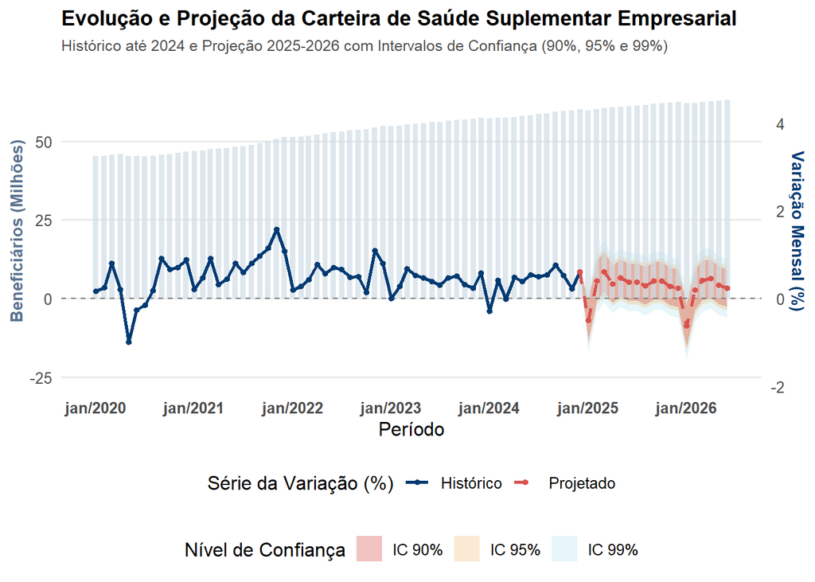

Para além das validações de especificação na amostra de teste, a utilidade prática do modelo para a tomada de decisão foi avaliada mediante o confronto direto das estimativas de estoque de vidas com os dados reais consolidados do TABNET/ANS para o $1º$ e $2º$ trimestres de 2026.A Tabela 3 apresenta a comparação entre o estoque real observado no mercado regulado e o projetado pelo modelo, acompanhado dos seus respectivos intervalos de predição estatística (IC 90%, IC 95% e IC 99%).

Tabela de Validação Out-of-Sample: Estoque de Beneficiários (2026)

| Data | Observado (TABNET) | Projeção (Modelo) | Intervalos de Confiança Intervalo 90% | Intervalos de Confiança Intervalo 95% | Intervalos de Confiança Intervalo 99% | Métricas de Erro Erro Absoluto (Mi) | Métricas de Erro Erro Absoluto (%) |
| --- | --- | --- | --- | --- | --- | --- | --- |
| 1T26 (Mar/26) | 62,63780 | 62,34910 | [61,48000 ; 63,22000] | [61,31000 ; 63,39000] | [60,98000 ; 63,72000] | 0,28870 | 0,46% |
| 2T26 (Jun/26) | 63,71169 | 62,97144 | [61,95000 ; 63,99000] | [61,75000 ; 64,19000] | [61,37000 ; 64,57000] | 0,74025 | 1,16% |

Como se observa na Tabela 3, os valores reais apurados pelo TABNET/ANS em Março/2026 ($62,64\text{ milhões}$) e Junho/2026 ($63,71\text{ milhões}$) mantiveram-se estritamente contidos dentro do Intervalo de Confiança de 90% do modelo (e, por consequência, contidos nas faixas de 95% e 99%). O desvio relativo de nível permaneceu extremamente reduzido e estável ao longo de 18 meses fora da amostra, registrando apenas $-0,46\%$ no 1T26 e $-1,16\%$ no 2T26.

A pequena diferença residual de nível decorre do filtro de cobertura do estudo (focado na compatibilização de planos médico-hospitalares e odontológicos), enquanto a base do TABNET agrega a totalidade assistencial com eventuais sobreposições de vínculos. Contudo, a proximidade das estimativas com o dado real e a permanência do mercado dentro das faixas teóricas de predição confirmam a alta precisão da calibração econométrica.

Por fim, este estudo visa fundamentar o entendimento sobre a dinâmica de beneficiários na modalidade coletiva empresarial, provendo subsídios estatísticos para tomadas de decisão estratégica, planejamento orçamentário, gestão de retenção e expansão de carteira. À medida que novas informações operacionais forem consolidadas pela agência reguladora e pelos órgãos públicos, as equações serão recalibradas para garantir o aprimoramento contínuo das projeções atuariais.